# assignment1v3

The first subplot shows that the distribution of new cases is highly skewed to the right, with a large proportion of states having a mode at zero new cases. The states with the highest mean new cases, NSW and Victoria, also have the highest density at higher values. The second subplot shows that the distribution of new deaths is also highly skewed to the right, with a large proportion of states having a mode at zero new deaths.

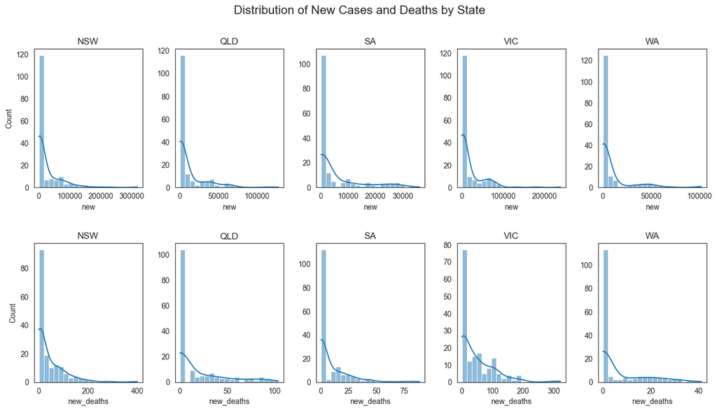

```python
fig, axes = plt.subplots(nrows=2, ncols=5, figsize=(16,8))

# loop through each state and plot its distribution in a separate subplot
for i, state in enumerate(['nsw', 'qld', 'sa', 'vic', 'wa']):
    state_cases = week_new[week_new['state'] == state]['new']
    state_deaths = week_new[week_new['state'] == state]['new_deaths']

    # plot histogram for new cases in the appropriate subplot
    sns.histplot(state_cases, bins=20, kde=True, ax=axes[0][i])

    # plot histogram for new deaths in the appropriate subplot
    sns.histplot(state_deaths, bins=20, kde=True, ax=axes[1][i])

    # set the title for the subplot
    axes[0][i].set_title(state.upper())
    axes[1][i].set_title(state.upper())

    # remove y-axis label for all subplots except the first one in each row
    if i > 0:
        axes[0][i].set_ylabel('')
        axes[1][i].set_ylabel('')

# set the overall title for the plot
fig.suptitle("Distribution of New Cases and Deaths by State", fontsize=16)
plt.subplots_adjust(wspace=0.3, hspace=0.4)
plt.show()
```

This code creates a 2x5 grid of subplots, each showing the distribution of new cases and new deaths for a different state.

```python
# Summary statistics of weekly new cases by state
print("Weekly New Cases by State")
week_new.groupby('state')['new'].describe().round(2)
```

```
Weekly New Cases by State
```

| state | count | mean | std | min | 25% | 50% | 75% | max |
| --- | --- | --- | --- | --- | --- | --- | --- | --- |
| nsw | 166.0 | 23877.04 | 45638.27 | 0.0 | 39.00 | 1601.5 | 28310.75 | 319632.0 |
| qld | 166.0 | 10917.43 | 21227.99 | 0.0 | 8.00 | 22.0 | 10063.75 | 127914.0 |
| sa | 166.0 | 5046.22 | 8830.82 | 0.0 | 3.00 | 13.0 | 6424.25 | 36203.0 |
| vic | 166.0 | 17902.10 | 33497.71 | 0.0 | 25.75 | 2473.5 | 16619.00 | 238588.0 |
| wa | 166.0 | 7949.01 | 18016.62 | 0.0 | 3.00 | 12.0 | 5024.00 | 102305.0 |

```python
# Summary statistics of weekly new deaths by state
print("Weekly New Deaths by State")
week_new.groupby('state')['new_deaths'].describe().round(2)
```

```
Weekly New Deaths by State
```

| state | count | mean | std | min | 25% | 50% | 75% | max |
| --- | --- | --- | --- | --- | --- | --- | --- | --- |
| nsw | 166.0 | 39.60 | 60.05 | 0.0 | 0.0 | 8.5 | 63.75 | 401.0 |
| qld | 166.0 | 17.08 | 27.43 | 0.0 | 0.0 | 0.0 | 28.00 | 104.0 |
| sa | 166.0 | 8.45 | 15.69 | 0.0 | 0.0 | 0.0 | 14.00 | 89.0 |
| vic | 166.0 | 44.72 | 57.74 | 0.0 | 0.0 | 26.0 | 72.75 | 322.0 |
| wa | 166.0 | 5.98 | 10.16 | 0.0 | 0.0 | 0.0 | 9.75 | 41.0 |

The mean weekly new cases in NSW were 23877.04, followed by VIC at 17902.10, QLD at 10917.43, WA at 7949.01, and SA at 5046.22. NSW also had the highest standard deviation in weekly new cases (45638.27), indicating that the number of new cases varied more significantly in NSW than in the other states.The maximum weekly new cases in VIC were 238588, followed by 319632 in NSW. VIC had the highest mean of new fatalities at 44.72, followed by NSW at 39.60, QLD at 17.08, SA at 8.45, and WA at 5.98. The maximum weekly new fatalities in VIC were 322, followed by 401 in NSW. Overall, it appears that NSW and VIC have had the largest weekly numbers of new cases and deaths, with NSW having a greater range of variance in new case counts. When compared to NSW and VIC, QLD, SA, and WA had lower mean numbers of new cases and deaths.

It's also worth mentioning that this analysis is based on summary information, and further research, such as hypothesis testing or modeling, would be required to draw more definitive conclusions about variances in the distribution of new cases and deaths across the five states.